# Tarea 2

Diabb Zegpi

25-12-2021

Este trabajo consiste en la utilización del chat del grupo de WhatsApp *“Magíster USS”*, grupo que conformamos todos los compañeros del Magíster en Data Science, generación 2020. Cabe aclarar que cuento con el consentimiento de mis compañeros para utilizar estos datos, razón por la que tendré los resguardos necesarios para no exponer conversaciones privadas o comprometedoras. Todos los mensajes fueron enviados en el período correspondido entre el 11 de junio y el 24 de diciembre de 2021.

El objetivo del proyecto es utilizar los datos de mensajes del grupo para predecir quién es autor(a) de un mensaje determinado.

Primero que todo, se cargan los paquetes de funciones a utilizar en el análisis.

```r
# Dependencias
library(tidyverse)
library(tidymodels)
library(textrecipes)
library(tidytext)
library(spacyr)
library(here)
library(stringi)
library(lubridate)
library(Matrix)
library(glmnet)
tidymodels_prefer()
```

Después, se importa el archivo con extensión *.txt* con los datos de conversaciones del grupo. Estos datos son una lista, en que cada nueva línea se compone por un mensaje nuevo o por un salto de línea dentro de un mensaje. Cada mensaje tiene el formato *6/11/2021 20:34 - Remitente: mensaje*. Este formato no es ideal para el análisis de datos, por esto, se recorre la lista de mensajes y saltos de líneas para formar un dataset con 3 columnas: `sender`, `datetime` y `message`.

```r
text <- read.delim("chat_wsp.txt",
                   encoding = "UTF-8",
                   quote = "",
                   sep = "\n",
                   col.names = "text",
                   skip = 1) %>%
  as_tibble()


text <- text$text
datetime_regex <- "^\\d{1,2}/\\d{1,2}/\\d{4} \\d{2}:\\d{2}"
j <- 1
sender <- vector("character")
datetime <- vector("character")
message <- vector("character")

for (i in 1:length(text)) {
  if (str_detect(text[i], datetime_regex)) {
    sender[j] <- str_match(text[i], "^.+ - (.+?): ")[,2]
    datetime[j] <- str_match(text[i], datetime_regex)[,1]
    message[j] <- str_match(text[i], "^.+: (.+)$")[,2]
    j <- j + 1
  } else {
    message[j] <- paste(message[j], text[i], sep = " ")
  }
}

chat <- tibble(
  sender = sender,
  datetime = datetime,
  message = message
)

head(chat)
```

```
## # A tibble: 6 x 3
##   sender           datetime        message
##   <chr>            <chr>           <chr>
## 1 Camila Rodríguez 11/6/2021 20:34 "<Multimedia omitido>"
## 2 Camila Rodríguez 11/6/2021 20:34 "<Multimedia omitido>"
## 3 Miguel Chandía   12/6/2021 08:33 "El profe se fue por qué no había nadie cone~
## 4 Danilo Sepúlveda 12/6/2021 08:34 "Buen día compañeros....vamos moviendo el cu~
## 5 Álvaro Reyes     12/6/2021 08:35 "Hahaha"
## 6 Magina Rojas     12/6/2021 08:35 "En serio??? JAJAJAJ"
```

El largo del dataset es de 6575 mensajes. Ha de notarse que muchos de ellos son contenido multimedia, sean como imágenes, audios o videos. Debido a que el análisis del contenido multimedia está fuera del alcance del proyecto, estos han sido omitidos, por ende, los mensajes de multimedia tienen que ser excluidos.

Otra característica del dataset es la codificación: hay caracteres con tildes y emoticones, los que serán removidos en pos de simplificar el análisis. El costo de esta operación es que el texto perderá interpretabilidad, debido a la remoción de tildes y de la letra *ñ*.

Como etapas finales de la preparación de datos, el texto se pasa a minúsculas y se quitan todos los caracteres que no sean letras del alfabeto latino. Adicionalmente, para mejorar el poder predictivo de los modelos posteriores, se crean las columnas `hour` y `week_day`.

```r
chat_clean <- chat %>%
  mutate(message = stri_trans_general(message, id = "Latin-ASCII"),
         message = str_replace_all(message, "[^\x01-\x7F]", ""),
         message = str_replace(message, "<Multimedia omitido>", ""),
         message = str_to_lower(message),
         message = str_replace_all(message, "[^a-z]", " "),
         message = str_replace_all(message, "\\s+", " "),
         date = as_date(str_sub(datetime, end = -7L), format = "%d/%m/%Y"),
         hour = as.numeric(str_sub(datetime, start = -5L, end = -4L)),
         week_day = wday(date, week_start = 1)) %>%
  select(-c(datetime, date)) %>%
  filter(!is.na(message) & str_length(message) > 0)
```

El dataset resultante tiene 4 variables y 5334 filas o mensajes, sin datos faltantes.

```r
head(chat_clean)
```

```
## # A tibble: 6 x 4
##   sender           message                                         hour week_day
##   <chr>            <chr>                                          <dbl>    <dbl>
## 1 Miguel Chandía   "el profe se fue por que no habia nadie conec~     8        6
## 2 Danilo Sepúlveda "buen dia companeros vamos moviendo el cuerpi~     8        6
## 3 Álvaro Reyes     "hahaha"                                           8        6
## 4 Magina Rojas     "en serio jajajaj"                                 8        6
## 5 Álvaro Reyes     "siuro "                                           8        6
## 6 Álvaro Reyes     "maravilloso"                                      8        6
```

## Partición en train y test

Previo a continuar el análisis exploratorio, se separará el dataset en conjuntos de training y testing, usando muestreo estratificado de acuerdo con el target (sender) y en proporciones 80 y 20%, respectivamente. Para tener una mejor estimación de la precisión de los modelos, podría usarse k-fold cross-validation, pero será obviado por las condiciones de hardware del equipo en que se trabaja.

```r
set.seed(123)
chat_split <- initial_split(chat_clean, prop = .8, strata = sender)
chat_train <- training(chat_split)
chat_test <- testing(chat_split)
```

## Exploración de mensajes

Se continuará con la exploración de la variable objetivo: sender. Un modelo clasificador tenderá a clasificar mejor la clase de la que vea más ejemplos. Por ello, es importante nivelar las clases para mejorar el rendimiento de los modelos subsecuentes.

[figure not shown]

```
## # A tibble: 13 x 4
##    sender                   n cumsum    pct
##    <chr>                <int>  <int>  <dbl>
##  1 Miguel Chandía         897    897 0.0225
##  2 Álvaro Reyes           740   1637 0.0411
##  3 Danilo Sepúlveda       465   2102 0.0527
##  4 Sebastián Navarro      351   2453 0.0615
##  5 José Luis Rivera       341   2794 0.0701
##  6 José Echeverría        247   3041 0.0763
##  7 Diabb                  226   3267 0.0820
##  8 Magina Rojas           226   3493 0.0876
##  9 Camila Rodríguez       213   3706 0.0930
## 10 Marcela Araneda        202   3908 0.0980
## 11 Katherine Barrientos   161   4069 0.102
## 12 Martín Burón           161   4230 0.106
## 13 Paula Vargas            37   4267 0.107
```

La media de mensajes enviados es igual a 328. Para los efectos del modelo de clasificación, se conservarán las etiquetas de las 5 personas más activas, porque tienen más de 300 mensajes, agrupando los 8 restantes en una sola categoría.

```r
sender_target <- chat_train %>%
  count(sender) %>%
  filter(n > 300) %>%
  pull(sender)

chat_train <- chat_train %>%
  mutate(sender = if_else(sender %in% sender_target,
                          sender,
                          "Otro"),
         sender = factor(sender))

chat_test <- chat_test %>%
  mutate(sender = if_else(sender %in% sender_target,
                          sender,
                          "Otro"),
         sender = factor(sender))
```

Otro asunto relevante es el comportamiento de los mensajes de acuerdo a la hora del día. Esto se explorará con diagramas de cajas.

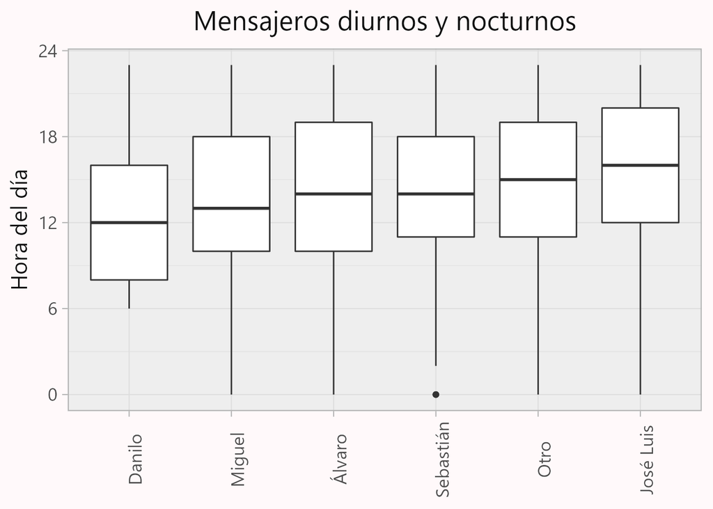

Por último, se explora el día de la semana como factor predictivo para el envío de mensajes.

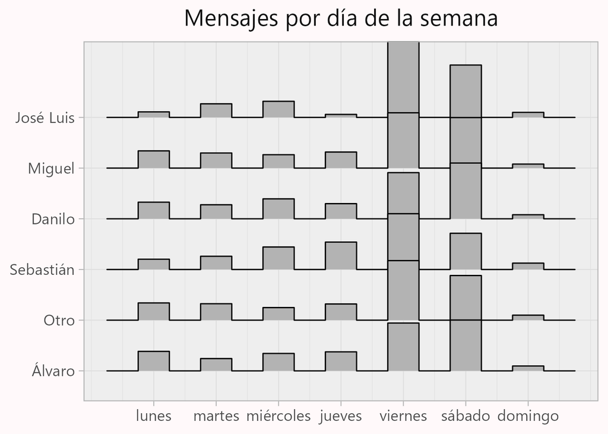

Aparentemente, más característico que el día de la semana para discriminar entre mis compañeros, es saber si ese día es lunes-martes-miércoles-jueves o viernes-sábado. Aún así, se mantendrán los días de la semana, sin transformar.

Finalmente, se examinan las palabras más comunes con una nube de palabras.

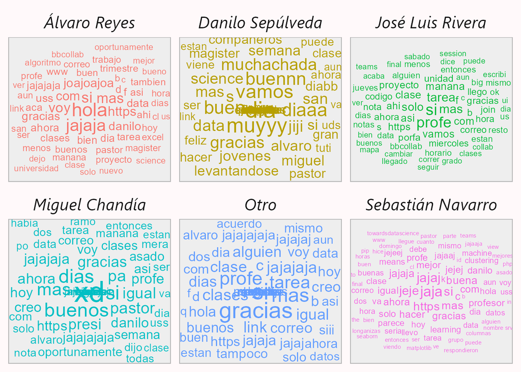

## Procesamiento de texto

A continuación, se especifica una secuencia de preprocesamiento, que posteriormente puede ser usada por los modelos. Estas etapas de preprocesamiento son:

1. Tokenizar los mensajes.
2. Excluir las stopwords en español de la lista SnowballC.
3. Lematizar con spaCy.
4. Filtrar a los 250 tokens más frecuentes.
5. Calcular tf-idf.

```r
spacy_initialize(model = "es_core_news_sm")

text_recipe <- recipe(sender ~ ., data = chat_train) %>%
  step_tokenize(message, engine = "spacyr") %>%
  step_stopwords(message, language = "es") %>%
  step_lemma(message) %>%
  step_tokenfilter(message, max_tokens = 250) %>%
  step_tfidf(message)
```

```r
library(discrim)
bayes_spec <- naive_Bayes() %>%
  set_mode("classification") %>%
  set_engine("naivebayes")

multinom_spec <- multinom_reg(penalty = .001, mixture = 1) %>%
  set_mode("classification") %>%
  set_engine("glmnet")
```

Posteriormente, se forma un workflow para cada modelo especificado, con el fin de organizar el entrenamiento y obtener predicciones con mayor sencillez.

```r
bayes_wf <- workflow() %>%
  add_recipe(text_recipe) %>%
  add_model(bayes_spec)

multinom_wf <- workflow() %>%
  add_recipe(text_recipe) %>%
  add_model(multinom_spec)
```

Ahora, se ajustan los modelos en el conjunto de entrenamiento.

```r
bayes_fit <- fit(bayes_wf, data = chat_train)
multinom_fit <- fit(multinom_wf, data = chat_train)

bayes_train_pred <- predict(bayes_fit, chat_train)
multinom_train_pred <- predict(multinom_fit, chat_train)
```

A continuación, se evalúan los modelos en el conjunto de entrenamiento.

```r
chat_train %>%
  bind_cols(bayes_train_pred) %>%
  accuracy(truth = sender, .pred_class)
```

```
## # A tibble: 1 x 3
##   .metric  .estimator .estimate
##   <chr>    <chr>          <dbl>
## 1 accuracy multiclass     0.405
```

```r
chat_train %>%
  bind_cols(multinom_train_pred) %>%
  accuracy(truth = sender, .pred_class)
```

```
## # A tibble: 1 x 3
##   .metric  .estimator .estimate
##   <chr>    <chr>          <dbl>
## 1 accuracy multiclass     0.502
```

Por otra parte, el modelo multinomial supera ampliamente al bayesiano, pero no supera un desempeño moderado. Al examinar el ajuste de este modelo se puede identificar a las variables con mayor influencia sobre la predicción.

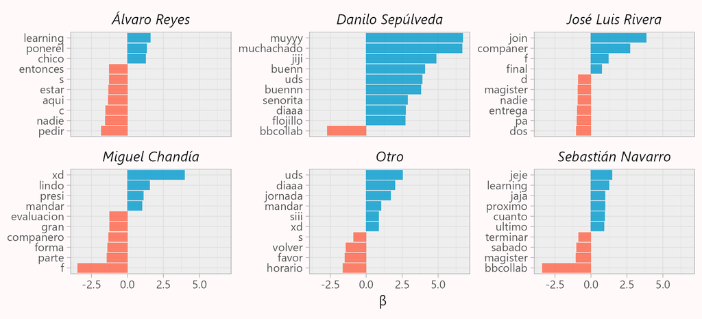

## Evaluación en conjunto de prueba

```r
multinom_test_pred <- predict(multinom_fit, new_data = chat_test)
```

```r
chat_test %>%
  bind_cols(multinom_test_pred) %>%
  accuracy(truth = sender, .pred_class)
```

```
## # A tibble: 1 x 3
##   .metric  .estimator .estimate
##   <chr>    <chr>          <dbl>
## 1 accuracy multiclass     0.441
```

En la prueba, el modelo multinomial tiene mucho peor desempeño que en el entrenamiento, dando una clara señal de sobreajuste.

```r
chat_test %>%
  bind_cols(multinom_test_pred) %>%
  conf_mat(truth = sender, .pred_class)
```

```
##                    Truth
## Prediction          Álvaro Reyes Danilo Sepúlveda José Luis Rivera
##   Álvaro Reyes                50               10                3
##   Danilo Sepúlveda             7               53                3
##   José Luis Rivera             5                1                7
##   Miguel Chandía              15               10                6
##   Otro                       116               40               65
##   Sebastián Navarro            0                1                3
##                    Truth
## Prediction          Miguel Chandía Otro Sebastián Navarro
##   Álvaro Reyes                  18   20                13
##   Danilo Sepúlveda               4    3                 0
##   José Luis Rivera               4    6                 4
##   Miguel Chandía                70   35                 5
##   Otro                         124  281                60
##   Sebastián Navarro              4   11                10
```

La matriz de confusión demuestra que la clase “Otro” se superpone con todas las demás, porque el modelo no logra discriminar entre nuestros mensajes, dado que hablamos todos sobre tópicos del magíster.

```r
testing_phrases <- tibble(
  message = c("Buenos días muchachada", "Danilo san", "Podríamos pedir más plazo para entregar la tarea", "Para cuándo quedó el asado?"),
  hour = c(7, 14, 23, 19),
  week_day = c(1, 4, 6, 5)
)

predict(multinom_fit, new_data = testing_phrases)
```

```
## # A tibble: 4 x 1
##   .pred_class
##   <fct>
## 1 Danilo Sepúlveda
## 2 Álvaro Reyes
## 3 Otro
## 4 Miguel Chandía
```

Pese al bajo accuracy del modelo, la predicción de estas 4 frases es satisfactoria. Por lo menos, se han identificado ciertos estilos y tópicos.

## Conclusiones

Hay dos enfoques para mejorar el modelo de predicción multiclase:

1. **data-centric**: conseguir más datos, mejorar la limpieza e incluir diccionarios, generar texto sintético para aumentar la muestra de las clases menos representadas, incluir emojis en el análisis, considerar la creación de la variable “fin de semana” y su interacción con las palabras tarea, clase y link, reescalar los datos, utilizar una lista de stopwords personalizada.
2. **algorithm-centric**: utilizar algoritmos basados en ensemble y boosting, cambiar el kernel del estimador bayesiano, utilizar model stacking, cambiar la configuración de regularización con grid search, cambiar el lematizador, evaluar con ROC AUC en lugar de accuracy, crear modelos escalonados para resolver el caso binario, después el de 3 niveles y así sucesivamente.

# Implementación de algoritmos no supervisados

A priori, la implementación del algoritmo LDA no debería ser prometedora, debido a que cada mensaje (*documento*) contiene pocas palabras. Esto significa que la frecuencia de palabras por documento no será alta y la *sparse matrix* será extremadamente *sparse*. Con el objeto de sortear este obstáculo, se filtran los mensajes con menos de 5 palabras.

```r
library(tm, include.only = "stopwords") # Cargar stopwords
library(topicmodels) # Algoritmo LDA
library(SnowballC) # Stemming

# Preprocessing
word_counts <- chat_clean %>%
  mutate(msg_id = row_number()) %>%
  filter(str_count(message, "\\S+") >= 5) %>% # Filtrar mensajes con menos de 5 palabras
  unnest_tokens(word, message, token = "words") %>%
  filter(!word %in% stopwords(kind = 'es')) %>%
  mutate(stem = wordStem(word, language = "spanish")) %>%
  count(msg_id, stem)

# Construir Document-Term-Matrix
message_dtm <- word_counts %>%
  cast_dtm(msg_id, stem, n)

message_dtm
```

```
## <<DocumentTermMatrix (documents: 2563, terms: 3535)>>
## Non-/sparse entries: 15527/9044678
## Sparsity           : 100%
## Maximal term length: 28
## Weighting          : term frequency (tf)
```

Como fue previsto, el atributo *Sparcity* tiene valor 100%, indicando la alta cantidad de tokens utilizados por pocos usuarios.

A continuación, se entrenan modelos LDA para $n = \left\{2,...,20\right\}$ tópicos y se calcula la métrica *perplexity* para evaluar los ajustes.

```r
library(doParallel)
ncores <- detectCores() - 1
cl <- makePSOCKcluster(ncores)
registerDoParallel(cl)

# Usar operador %dopar% de computación paralela
lda_models <- foreach(ntopics = 2:20) %dopar% {
 topicmodels::LDA(message_dtm, k = ntopics, control = list(seed = 123))
}

stopImplicitCluster()
```

```r
perplexities <- map_dbl(lda_models, perplexity) %>%
  enframe(name = "ntopics", value = "perplexity") %>%
  transmute(ntopics = ntopics + 1, perplexity = perplexity)
```

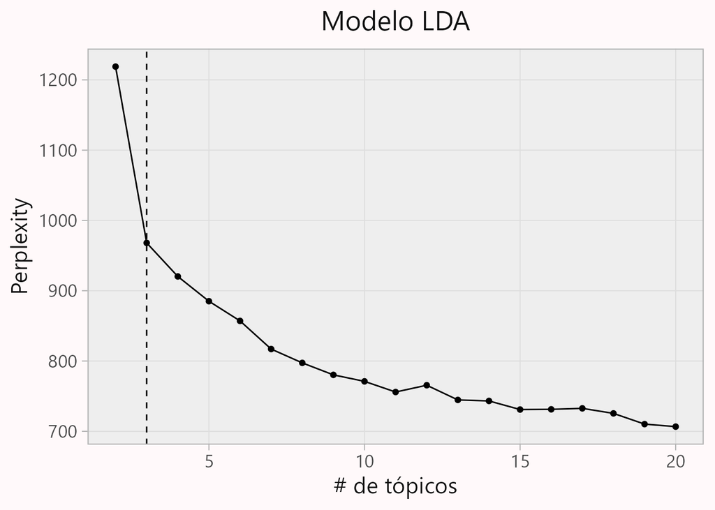

Ahora, tras seleccionar el mejor modelo, se extraen las matrices de distribución de probabilidad de término por tópico (beta) y distribución de probabilidad de tópico por documento (gamma).

```r
best_model <- lda_models[[2]] # modelo de 3 tópicos
beta_matrix <- tidy(best_model, matrix = "beta")
gamma_matrix <- tidy(best_model, matrix = "gamma")

top_terms <- beta_matrix %>%
  group_by(topic) %>%
  slice_max(beta, n = 10, with_ties = FALSE) %>%
  ungroup()
```

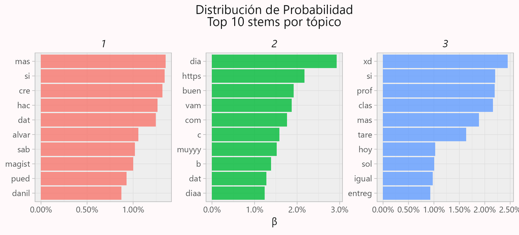

## Análisis con redes

Como elección personal, se empleará el coeficiente $\phi$ para estimar la correlación entre las palabras más comunes. El resultado esperado será encontrar nodos conectados a muchas palabras, formando conglomerados semánticamente identificables.

```r
library(widyr)

stems <- chat_clean %>%
  mutate(msg_id = row_number()) %>%
  unnest_tokens(word, message, token = "words") %>%
  mutate(stem = wordStem(word, language = "spanish"))

chat_cors <- stems %>%
  group_by(stem) %>%
  filter(n() > 20) %>% # filtrar palabras menos comunes
  pairwise_cor(stem, msg_id)
```

En la figura siguiente se observa un cluster evidente que dice de los enlaces de conexión para las clases. También existe una fuerte conexión entre los saludos de buenos días y las bromas de “pastor y diezmos”. Por el sector izquierdo, se notan las correlaciones entre asignaturas de proyectos y preguntas para las/os profesores. Por último, nótese la alta correlación entre `Python` y `R`, lo que denota las preferencias de la universidad sobre lenguajes de programación a impartir en el postgrado.

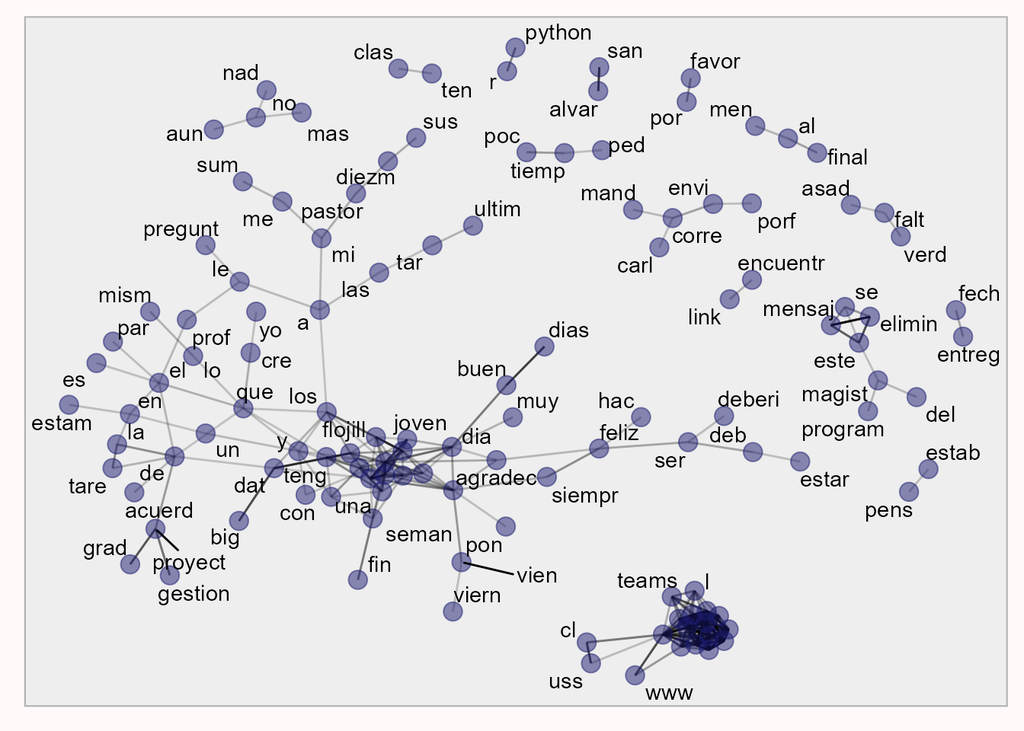